# ggplot2を利用したデータ可視化の基礎

## 5.5 散布図

2つのデータの関係性を可視化するグラフの代表格は散布図である。散布図は以下のようにして描く。

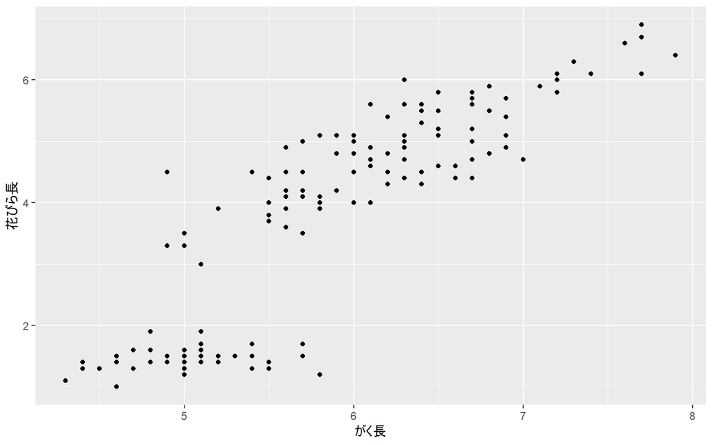

```r
g <- ggplot(data_iris)+
  geom_point(aes(x=がく長, y=花びら長))
plot(g)
```

### 5.5.1 種類ごとに色分け

`geom_point()`の`aes()`に`color`を与える。

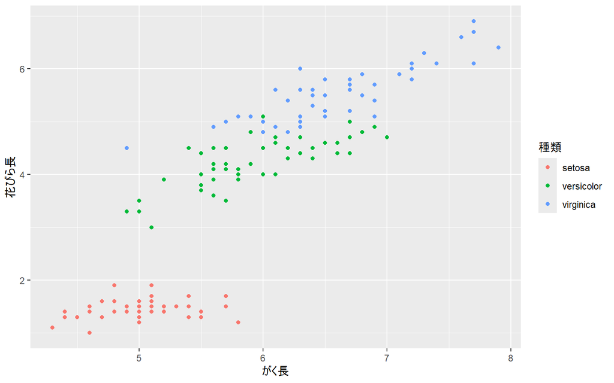

```r
g <- ggplot(data_iris)+
  geom_point(aes(x=がく長, y=花びら長, color=種類))
plot(g)
```

### 5.5.2 種類ごとにプロットの形を分ける

`geom_point()`の`aes()`に`shape`を与える。

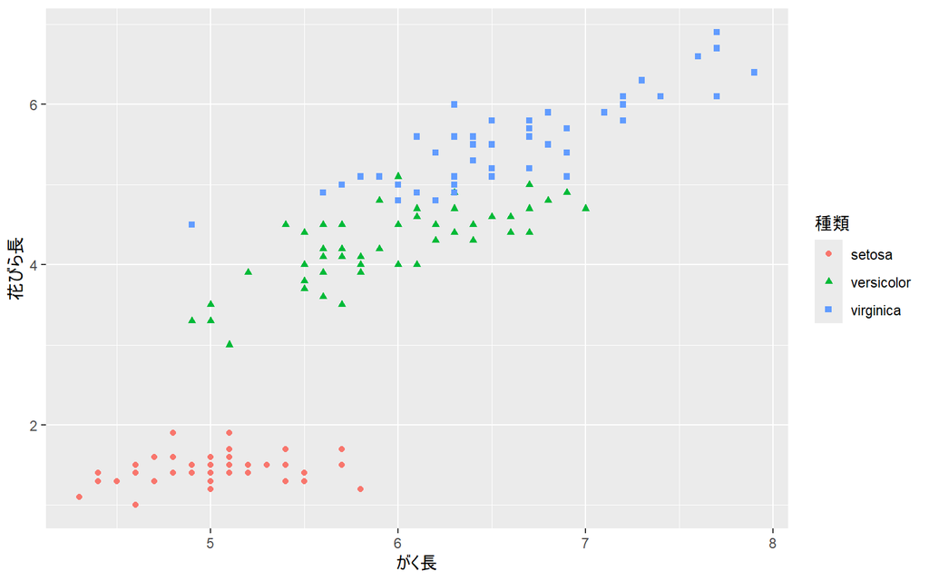

```r
g <- ggplot(data_iris)+
  geom_point(aes(x=がく長, y=花びら長, color=種類, shape=種類))
plot(g)
```

分かりやすく、がく長と花びら長に関係性として、setosaにはほぼ関係性はないが、versicolorとvirginicaにはがく長が長くなると、花びら長も長くなる傾向にあることが分かった。

散布図は回帰分析を行う際の結果の可視化でも改めて触れることにする。

## 5.6 任意の位置に文字や図形を書き入れる

任意の場所に任意の文字や線、図形を書き入れる場合には、`annotate()`関数を使う。以下のように、`geom_point()`の後に`annotate()`を使って、任意の位置に任意の文字を書き入れることができる。以下に代表的な引数を示す。これら以外にも円を描いたり、矢印を描いたりできるので、興味がある人はChatGPTに聞いてみてほしい。

| 引数名 | 内容 |
| --- | --- |
| 第1引数 | アノテーションの種類の指定。“text”(テキスト)、“segment”(線分)、“rect”(四角形)などがある |
| x,y | アノテーションを書き入れるx,y座標 |
| xend | 線を引く場合の終点のx座標 |
| yend | 線を引く場合の終点のy座標 |
| xmin, xmax, ymin, ymax | 四角形を描く場合の座標 |
| label | 書き入れる文字列 |
| color | 文字の色、線の色 |
| fill | 四角形の塗りつぶしの色 |
| size | 文字の大きさ |
| angle | 文字の角度 |
| linewidth | 線の幅 |

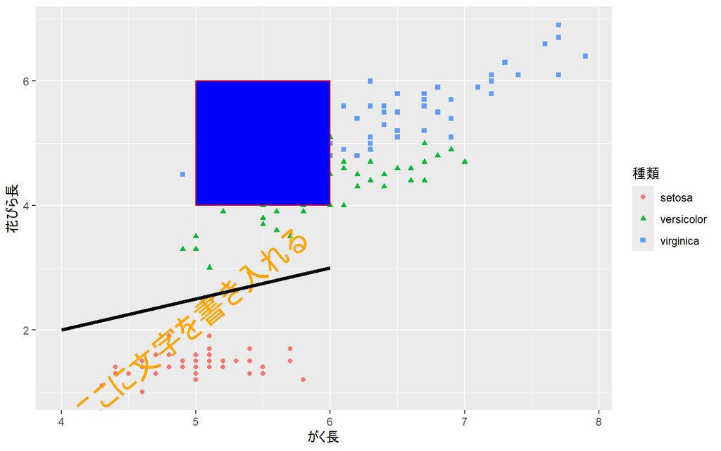

```r
g <- ggplot(data_iris)+
  geom_point(aes(x=がく長, y=花びら長, color=種類, shape=種類))+
  annotate("text", x=5, y=2, label="ここに文字を書き入れる",color="orange",size=7, angle=39)+
  annotate("segment", x=4, y=2, xend=6, yend=3, linewidth=1.5)+
  annotate("rect", xmin=5, xmax=6, ymin=4, ymax=6,color="red",fill="blue")
plot(g)
```

# 6 書式や凡例を弄る

## 6.1 軸のタイトルを消したり書き換えたり

デフォルトでは軸タイトルは`aes()`で設定した各軸の変数名がそのまま入るが、`xlab`や`ylab`を使って自分の好きなように変えることができる。 引数に`NULL`を設定すると軸タイトルを消せる。

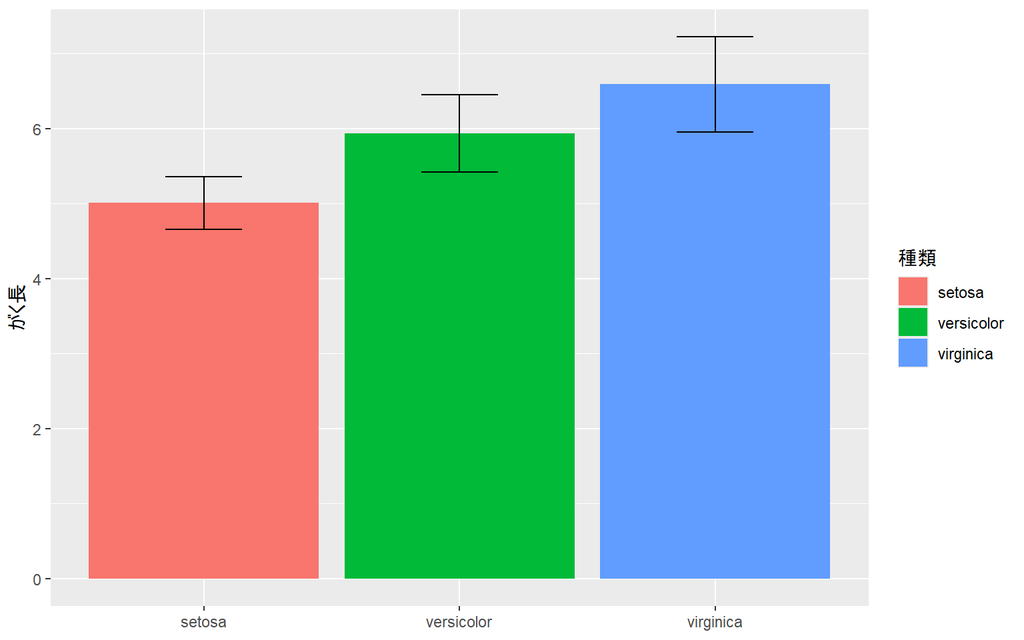

```r
g <- ggplot(d2,aes(x=種類,y=平均))+
  geom_bar(aes(fill=種類),stat="identity")+
  geom_errorbar(aes(ymin=平均-標準偏差, ymax=平均+標準偏差,width=0.3))+
  xlab(NULL)+ylab("がく長")
plot(g)
```

## 6.2 凡例タイトルを書き換える

`labs()`を使う。 引数には、`aes()`で色を指定するときに使った引数に、書き換えたいタイトルを与える。 以下の例では、`fill`を使って色を与えているので、`fill=****`というのを引数としてlabelに与える。

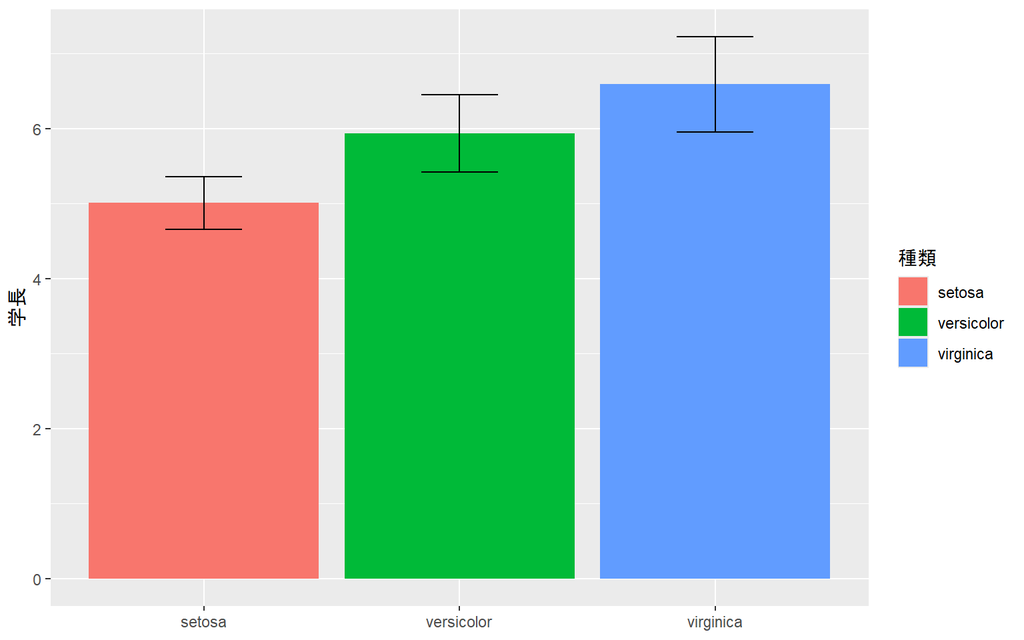

```r
g <- ggplot(d2,aes(x=種類,y=平均))+
  geom_bar(aes(fill=種類),stat="identity")+
  geom_errorbar(aes(ymin=平均-標準偏差, ymax=平均+標準偏差,width=0.3))+
  xlab(NULL)+ylab("学長")+labs(fill="種類")
plot(g)
```

ちなみにlabsは引数として以下のものを取る。

| 項目 | 内容 |
| --- | --- |
| title | タイトル |
| subtitle | サブタイトル |
| x | x軸ラベル |
| y | y軸ラベル |
| caption | キャプション |
| fill またはcolor | 凡例ラベルのタイトル |

この通りに、xlabやylabもlabsでまとめて設定することもできる。

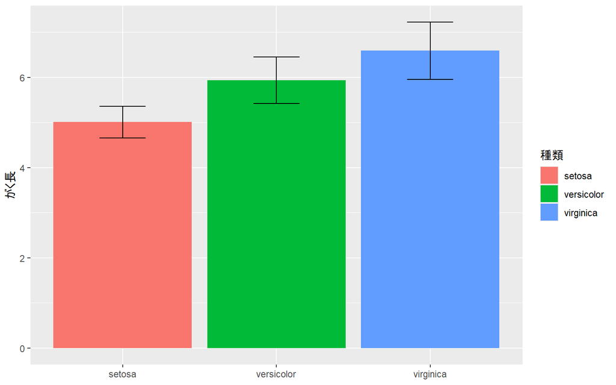

```r
g <- ggplot(d2,aes(x=種類,y=平均))+
  geom_bar(aes(fill=種類),stat="identity")+
  geom_errorbar(aes(ymin=平均-標準偏差, ymax=平均+標準偏差,width=0.3))+
  labs(x=NULL, y="がく長", fill="種類")
plot(g)
```

## 6.3 凡例を消す

`theme(legend.position = "none")`を使う。

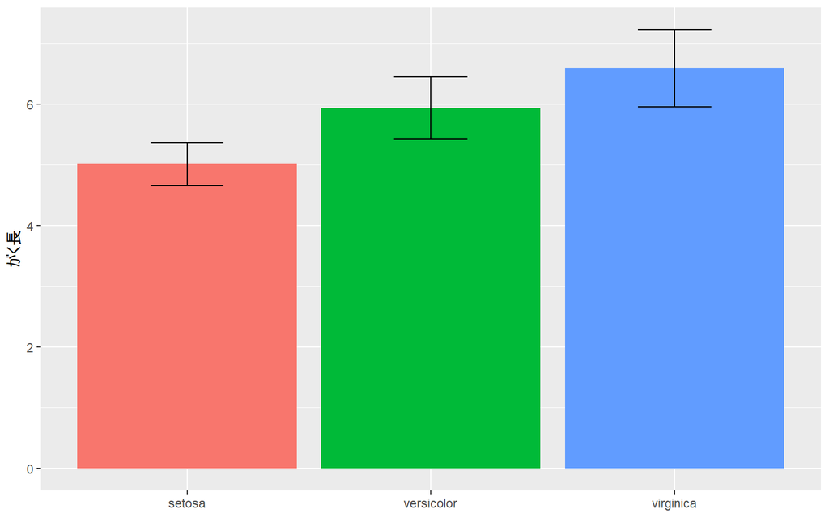

```r
g <- ggplot(d2,aes(x=種類,y=平均))+
  geom_bar(aes(fill=種類),stat="identity")+
  geom_errorbar(aes(ymin=平均-標準偏差, ymax=平均+標準偏差,width=0.3))+
  xlab(NULL)+ylab("がく長")+
  theme(legend.position = "none")
plot(g)
```

## 6.4 軸タイトルや軸ラベル、凡例の文字サイズを換える

凡例を消した時と同じようにthemeを使う。引数には以下のようなものを入れる。 `axis.text.x=element_text(size=15)` `axis.text.y=element_text(size=15)` `axis.title.x=element_text(size=15)` `axis.title.y=element_text(size=15)` `legend.text=element_text(size=9)`

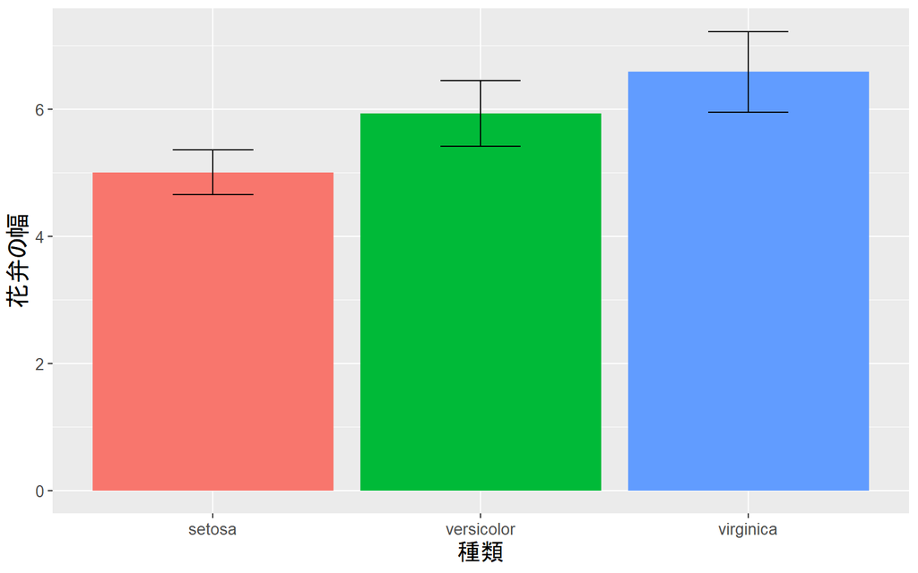

```r
g <- ggplot(d2,aes(x=種類,y=平均))+
  geom_bar(aes(fill=種類),stat="identity")+
  geom_errorbar(aes(ymin=平均-標準偏差, ymax=平均+標準偏差,width=0.3))+
  xlab("種類")+ylab("花弁の幅")+
  theme(legend.position = 'none')+
  theme(
    axis.title.x=element_text(size=15),
    axis.title.y=element_text(size=15),
    axis.text.x=element_text(size=10),
    axis.text.y=element_text(size=10),
    legend.text=element_text(size=5),
    legend.title = element_text(size=8)  )

plot(g)
```

themeの設定項目

themeは細かくいろいろ設定できる。設定できるものは以下の通り。

| 名前 | 説明 | 要素の型 |
| --- | --- | --- |
| text | すべてのテキスト要素 | element_text() |
| axis.title | 両軸ラベルの体裁 | element_text() |
| axis.title.x | x軸ラベルの体裁 | element_text() |
| axis.title.y | y軸ラベルの体裁 | element_text() |
| axis.text | 両軸目盛ラベルの体裁 | element_text() |
| axis.text.x | x軸目盛ラベルの体裁 | element_text() |
| axis.text.y | y軸目盛ラベルの体裁 | element_text() |
| legend.text | 凡例項目の体裁 | element_text() |
| legend.title | 凡例タイトルの体裁 | element_text() |
| plot.title | タイトルの体裁 | element_text() |
| strip.text | 両方向ファセットラベルテキストの体裁 | element_text() |
| strip.text.x | 水平方向ファセットラベルテキストの体裁 | element_text() |
| strip.text.y | 垂直方向ファセットラベルテキストの体裁 | element_text() |
| legend.position | 凡例の位置 | left, right, bottom, top, c(x,y) :x,yは0~1 |
| legend.background | 凡例の背景 | element_rect(fill=“xxx”, color=“yyy”) fillは塗りつぶし、colorは枠線 |
| plot.background | プロット全体の背景 | element_rect(fill=“xxx”, color=“yyy”) |
| panel.background | プロット領域の背景 | element_rect() |
| panel.border | プロット領域の枠線 | element_rect(linetype=“xxx”) |
| rect | 全ての長方形要素 | element_rect() |
| panel.grid.major | 主目盛線 | element_line() |
| panel.grid.major.x | 主目盛線の垂直方向 | element_line() |
| panel.grid.major.y | 主目盛線の水平方向 | element_line() |
| panel.grid.minor | 補助目盛線 | element_line() |
| panel.grid.minor.x | 補助目盛線の垂直方向 | element_line() |
| panel.grid.minor.y | 補助目盛線の水平方向 | element_line() |
| axis.line | 軸に沿った線 | element_line() |
| line | すべての線要素 | element_line() |

引用（順序は改変しました）：https://knknkn.hatenablog.com/entry/2019/02/23/181311

element_text()の設定項目

| 設定項目 | element_text()の引数 |
| --- | --- |
| 角度 | angle |
| 水平位置 | hjust(0:左揃え～1:右揃え) |
| 垂直位置 | vjust(0:下揃え～1:上揃え) |
| サイズ | size |
| 色 | colour |
| スタイル | face(bold or italic) |
| フォントファミリー | family |

参考：http://mukkujohn.hatenablog.com/entry/2016/10/11/220722

element_xxxのその他の項目 `element_rect(fill, color, size, linetype, inherit.blank)` — 長方形

| 項目 | 内容 |
| --- | --- |
| fill | 塗りつぶしの色 |
| color | 枠の色 |

`element_line(color, size, linetype, lineend, arrow, inherit.blank)`— 線

`element_blank()` — 空 消したい要素にはこれを指定する

参考：https://heavywatal.github.io/rstats/ggplot2.html

## 6.5 目盛ラベルを変える

目盛ラベルを変えるには、`scale_x_****`や`scale_y_***`を使う。 以下は、x軸の目盛りをsetosa, versicolor, virgnicaから、a, b, cに変え、y軸を普通の目盛から対数目盛に変えた例である。

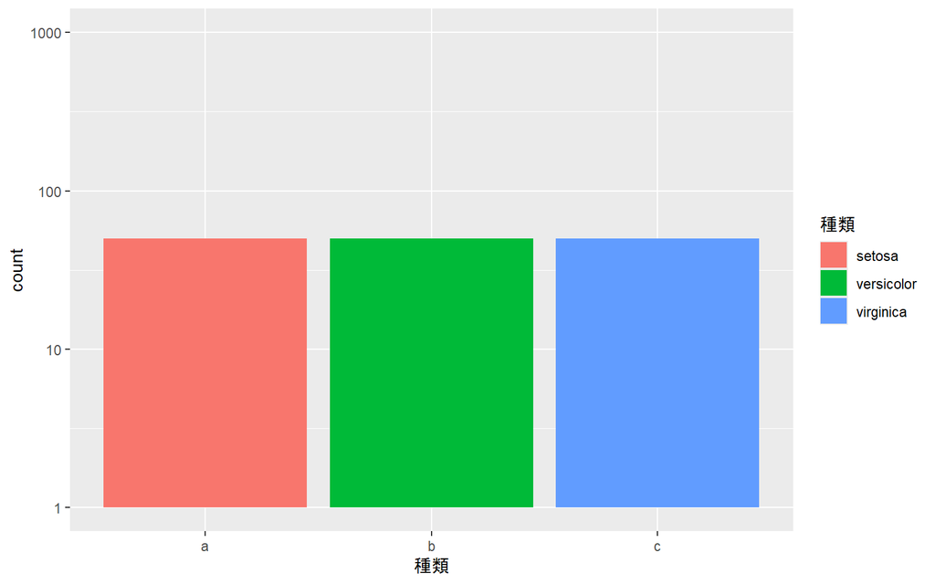

```r
g <- ggplot(data_iris)+
  geom_bar(aes(x=種類,fill=種類),stat="count") +
  scale_x_discrete(labels=c("a","b","c"))+
  scale_y_log10(limits=c(1,1000))
plot(g)
```

`***`の部分には、いずれも以下のものが入る。

| *** | 内容 |
| --- | --- |
| discrete | 離散目盛 |
| continuous | 連続目盛 |
| log10 | 対数目盛 |
| reverse | 目盛の逆転 |
| sqrt | 平方根目盛 |

また、代表的な引数としては以下のものが入る。

| 引数 | 内容 |
| --- | --- |
| labels | 離散目盛のラベルを変える（以下のbreaksを併用すると、連続変数でも可能） |
| breaks | 連続変数の目盛のうち指定したものだけを表示させる |
| limits | 連続変数の表示範囲を指定したものにする.xlim,ylimと同じ効果。 |
| name | 変数の軸ラベルを変える。xlab,ylabと同じ効果。 |

結局、軸タイトルを変える方法って、色々あるということである。 xlabでもよいし、labs(x=)dでもよいし、scale_x_***(name=)でも変えれる。

## 6.6 凡例の各項目のラベルを書き換える。

グループ分けにfillを使っている場合は、`sacle_fill_dicrete()`を、Colorを使っている場合は`scale_color_discrete()`を使う。

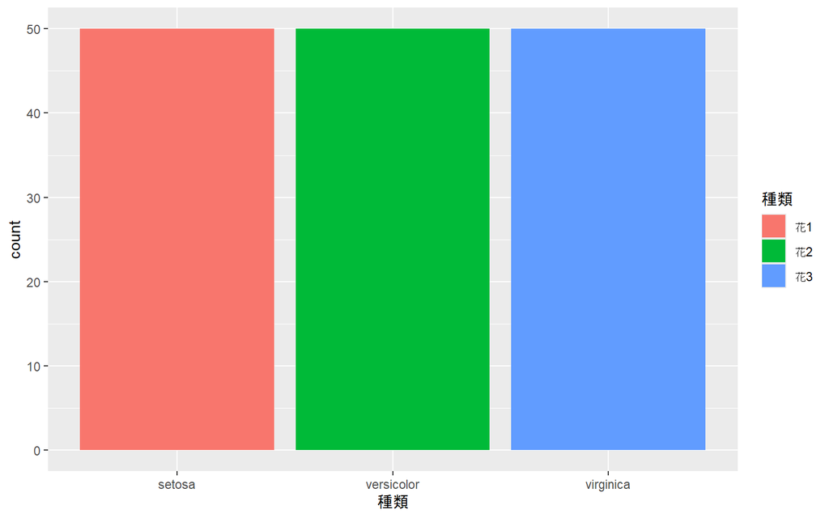

```r
g <- ggplot(data_iris)+
  geom_bar(aes(x=種類,fill=種類),stat="count")+
  scale_fill_discrete(label=c("花1","花2","花3"))
plot(g)
```